# 1 Background

As a statistical consultant working for a real estate investment firm, your task is to develop a model to predict the selling price of a given home in Ames, Iowa. Your employer hopes to use this information to help assess whether the asking price of a house is higher or lower than the true value of the house. If the home is undervalued, it may be a good investment for the firm.

# 2 Training Data and relevant packages

In order to better assess the quality of the model you will produce, the data have been randomly divided into three separate pieces: a training data set, a testing data set, and a validation data set. For now we will load the training data set, the others will be loaded and used later.

```r
load("ames_train.Rdata")
```

Use the code block below to load any necessary packages

```r
library(devtools)
library(statsr)
library(dplyr)
library(BAS)
library(MASS)
library(ggplot2)
library(kableExtra)
```

## 2.1 Data Pre-processing

First let us look at the structure of the data to check if all variables are correctly incorporated.

```r
str(ames_train)
```

```
## Classes 'tbl_df', 'tbl' and 'data.frame':    1000 obs. of  81 variables:
##  $ PID            : int  909176150 905476230 911128020 535377150 534177230 908128060 902135020 528228540 923426010 908186050 ...
##  $ area           : int  856 1049 1001 1039 1665 1922 936 1246 889 1072 ...
##  $ price          : int  126000 139500 124900 114000 227000 198500 93000 187687 137500 140000 ...
##  $ MS.SubClass    : int  30 120 30 70 60 85 20 20 20 180 ...
##  $ MS.Zoning      : Factor w/ 7 levels "A (agr)","C (all)",..: 6 6 2 6 6 6 7 6 6 7 ...
##  $ Lot.Frontage   : int  NA 42 60 80 70 64 60 53 74 35 ...
##  $ Lot.Area       : int  7890 4235 6060 8146 8400 7301 6000 3710 12395 3675 ...
##  $ Street         : Factor w/ 2 levels "Grvl","Pave": 2 2 2 2 2 2 2 2 2 2 ...
##  $ Alley          : Factor w/ 2 levels "Grvl","Pave": NA NA NA NA NA NA 2 NA NA NA ...
##  $ Lot.Shape      : Factor w/ 4 levels "IR1","IR2","IR3",..: 4 4 4 4 4 4 4 4 4 4 ...
##  $ Land.Contour   : Factor w/ 4 levels "Bnk","HLS","Low",..: 4 4 4 4 4 4 1 4 4 4 ...
##  $ Utilities      : Factor w/ 3 levels "AllPub","NoSeWa",..: 1 1 1 1 1 1 1 1 1 1 ...
##  $ Lot.Config     : Factor w/ 5 levels "Corner","CulDSac",..: 1 5 5 1 5 1 5 5 1 5 ...
##  $ Land.Slope     : Factor w/ 3 levels "Gtl","Mod","Sev": 1 1 1 1 1 1 2 1 1 1 ...
```

[output cut: 67 more lines]

We see that all the variables have the correct data types except for PID and MS.SubClass. We will not be using PID in our analysis as it is the Parcel Identification Number and has nothing to do with the property itself. However Ms.SubClass should be a factor so we will change that first.

```r
ames_train$MS.SubClass <- as.factor(ames_train$MS.SubClass)
```

## 2.2 Part 1 - Exploratory Data Analysis (EDA)

*When you first get your data, it’s very tempting to immediately begin fitting models and assessing how they perform. However, before you begin modeling, it’s absolutely essential to explore the structure of the data and the relationships between the variables in the data set.

Do a detailed EDA of the ames_train data set, to learn about the structure of the data and the relationships between the variables in the data set (refer to Introduction to Probability and Data, Week 2, for a reminder about EDA if needed). Your EDA should involve creating and reviewing many plots/graphs and considering the patterns and relationships you see.

After you have explored completely, submit the three graphs/plots that you found most informative during your EDA process, and briefly explain what you learned from each (why you found each informative).*

### 2.2.1 Distribution of Prices

The ultimate aim of this project is to deliver an accurate analysis of whether certain houses are overvalued or undervalued so that the real estate investment firm could make an informed choice. This means that the aspect of the data we are interested in is the **price**, since this will help us assess whether the asking price of a house is too high or too low.

Thus, it is a good idea to look at the distribution of the variable price in the dataset. It will help us gain an understanding of the dynamics of the dataset as well as provide insight into whether linear regression is a suitable predictive method since it requires nearly normally distributed data to come up with valid predictions.

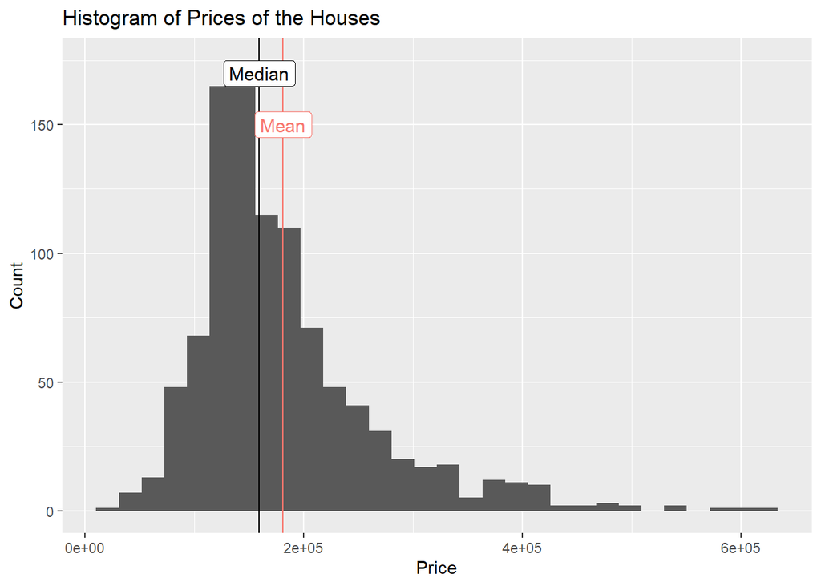

```r
#Histogram of Prices
ggplot(data = ames_train, aes(x = price)) + geom_histogram() +
  labs(title = "Histogram of Prices of the Houses", x = "Price", y = "Count") +
  geom_vline(aes(xintercept = mean(ames_train$price), colour = "red")) +
  geom_vline(aes(xintercept = median(ames_train$price))) +
  geom_label(aes(x = mean(ames_train$price), y = 150, label = "Mean", color = "red"), size = 4, parse = T) +
  geom_label(aes(x = median(ames_train$price), y = 170, label = "Median"), size = 4, parse = T) +
  theme(legend.position = "none")
```

From the histogram, we can see that the prices are nearly normally distributed with a slight right skew. Let us also calculate some summary statistics to check if this is indeed the case.

```r
ames_train %>% summarise(Mean = mean(price), SD = sd(price),
                         Q1 = quantile(price, 0.25), Median = median(price),
                         Q3 = quantile(price, 0.75)) %>% kable() %>% kable_styling()
```

| Mean | SD | Q1 | Median | Q3 |
| --- | --- | --- | --- | --- |
| 181190.1 | 81909.79 | 129762.5 | 159467 | 213000 |

From the summary statistics, we can see that the mean is indeed higher than the median which means that the price data is right-skewed. From the previous weeks of assessments, we know that abnormal sale conditions can often affect prices substantially. Let’s filter out only the normal sale data and create a histogram to see if the distribution is similar.

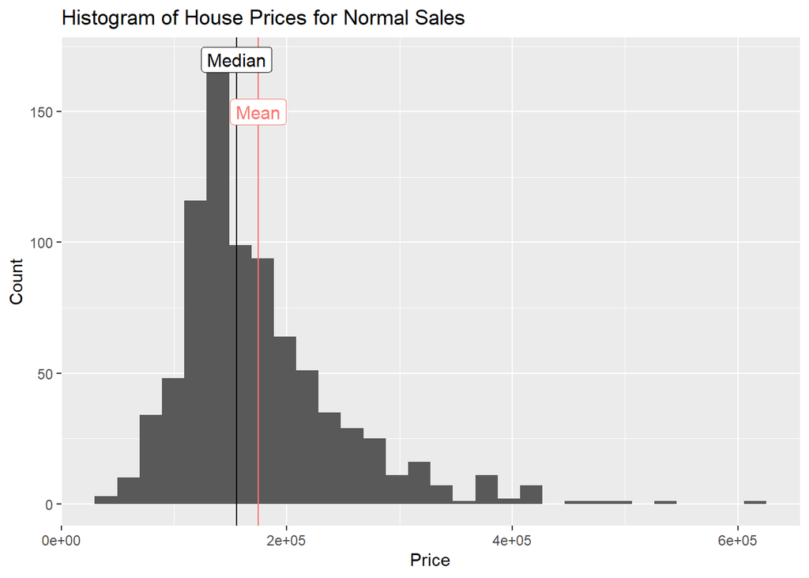

```r
ames_filtered <- ames_train %>% filter(Sale.Condition == "Normal")

#Histogram of Prices of Normal Sale
ggplot(data = ames_filtered, aes(x = price)) + geom_histogram() +
  labs(title = "Histogram of House Prices for Normal Sales", x = "Price", y = "Count") +
  geom_vline(aes(xintercept = mean(ames_filtered$price), colour = "red")) +
  geom_vline(aes(xintercept = median(ames_filtered$price))) +
  geom_label(aes(x = mean(ames_filtered$price), y = 150, label = "Mean", color = "red"), size = 4, parse = T) +
  geom_label(aes(x = median(ames_filtered$price), y = 170, label = "Median"), size = 4, parse = T) +
  theme(legend.position = "none")
```

```r
#Summary Statistics
ames_filtered %>% summarise(Mean = mean(price), SD = sd(price),
                         Q1 = quantile(price, 0.25), Median = median(price),
                         Q3 = quantile(price, 0.75)) %>% kable() %>% kable_styling()
```

| Mean | SD | Q1 | Median | Q3 |
| --- | --- | --- | --- | --- |
| 174622.3 | 72269.79 | 129000 | 155500 | 205000 |

The shape of the histogram looks similar to the unfiltered data - nearly normally distributed with a slight right skew. From the summary statistics, we can see that the variability of the Normal Sale data is lower since the Standard Deviation has gone down from 81909 for unfiltered data to 72269 for Normal sale prices. The mean, median and the third quartile have all decreased in values as well, implying that some of the removed not-normal sale data were on the higher end of prices. From now on, we will only use the filtered data for our modelling and analysis.

### 2.2.2 Location and Property Pricing

In this section we will look at if and how the location of the house affects its valuation. For this purpose, We will use the variables Neighborhood (the neighborhood the property is located in) and Condition.1 (proximity of the house to various conditions).

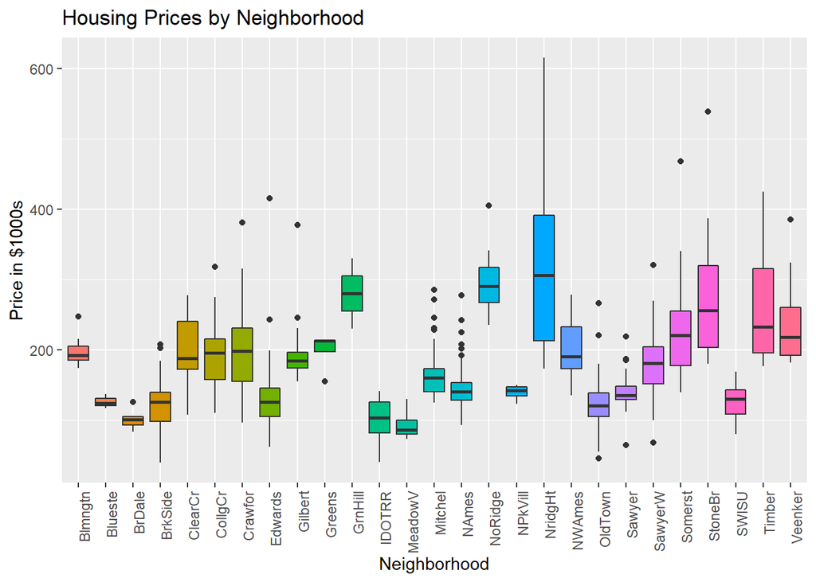

```r
# Boxplots of Housing Prices by Neighborhood
ggplot(ames_filtered, aes(x = Neighborhood, y = price/1000, fill = Neighborhood)) +
  scale_fill_discrete(guide =FALSE) + geom_boxplot() +  labs(title = "Housing Prices by Neighborhood",
                                                             x = "Neighborhood", y = "Price in $1000s") +
  theme(axis.text.x = element_text(angle = 90, hjust =1))
```

From this plot, we can see that different neighborhoods indeed have different interquartile range brackets for prices. The prices of houses in NorthRidge Heights are widely variable whereas for NorthPark Villa, the prices are low and comparatively homogeneous. The different neighborhood areas also have different average prices - for instance, the entire price range of houses in Meadow Village is completely below the price range of houses in Green Hills with none to minimal overlaps. This suggests that neighborhoods would be a significant factor for prediction of prices.

Let’s look at how the proximity to various conditions affect the prices of property.

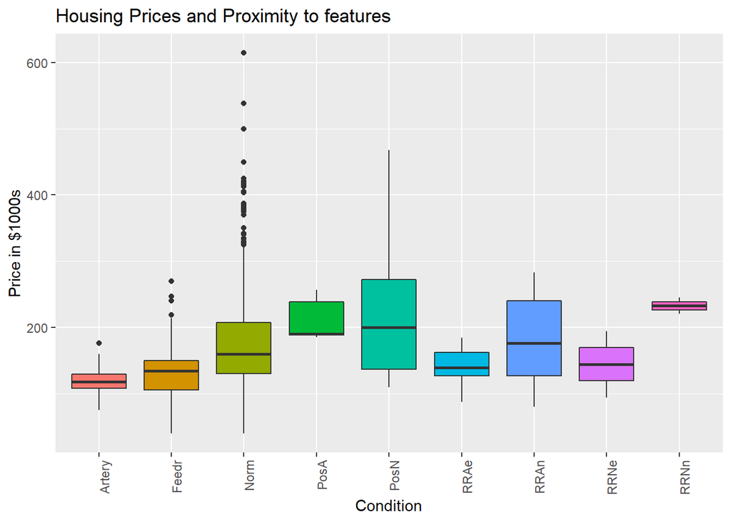

```r
# Proximity to conditions
ggplot(ames_filtered, aes(x = Condition.1, y = price/1000, fill = Condition.1)) +
  scale_fill_discrete(guide =FALSE) + geom_boxplot() + theme(axis.text.x = element_text(angle = 90,
                                                                                        hjust =1)) +
  labs(title = "Housing Prices and Proximity to features ", x = "Condition", y = "Price in $1000s")
```

We see that houses within 200’ of the North-South Railroad (denoted by RRNn) are on average sold for higher prices than houses adjacent to the East West Railroad (denoted by RRAe). However, the difference in prices are not dramatically different for the Condition categories, i.e., there is significant overlap in the price ranges. These minor differences in prices may be due to proximity to these conditions but they can also just be a consequence of the location itself and may have nothing to do with these conditions.

### 2.2.3 Year Built and Prices

We could expect that new houses sell for higher prices since they are less likely to require refurbishments. We can now plot the log(price) of house against the year it was built to check if this is true. We will also include the variable Overall.Cond (overall condition of house) in the plot since this is our theory for why newer houses may be priced higher.

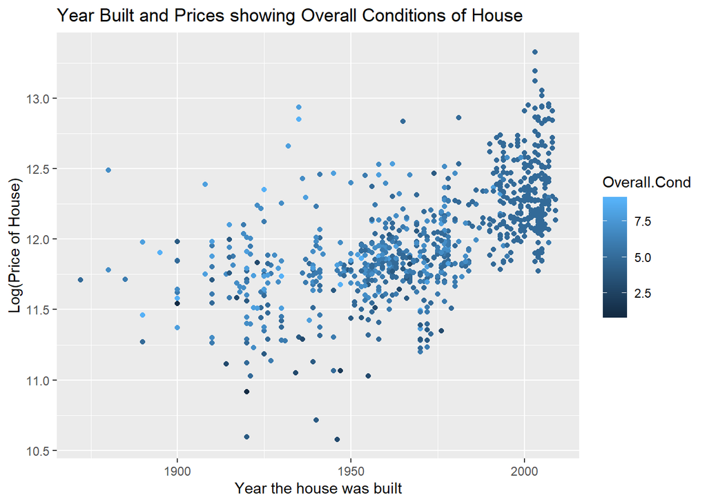

```r
# Year Built and Price
ggplot(ames_filtered, aes(x = Year.Built, y=log(price), col = Overall.Cond)) + geom_point() +
  labs(title="Year Built and Prices showing Overall Conditions of House", x="Year the house was built",
       y = "Log(Price of House)")
```

As expected, we see that the plot shows an upward trend indicating that prices indeed go up for the newly built houses. However, the overall condition of the houses do not seem to be increasing with newer houses since we see darker dots for years past 2000 and quite a few ligher dots before 2000. Let’s plot Overall.Cond against Year.Built to see if we are getting the trend right.

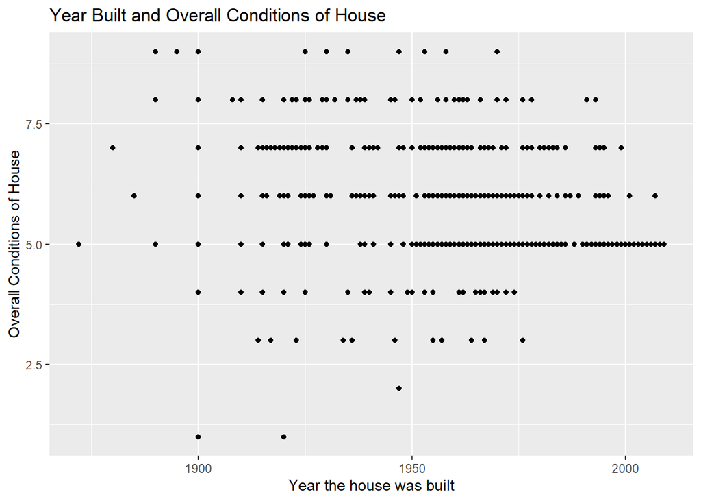

```r
ggplot(ames_filtered, aes(x = Year.Built, y=Overall.Cond)) + geom_point() +
  labs(title="Year Built and Overall Conditions of House", x="Year the house was built",
       y = "Overall Conditions of House")
```

The above plot shows that the overall conditions don’t necessarily increase for newer houses. In fact, for houses built after 2000, the overall conditions were mostly rated at 5 and 6. Almost all the houses rated 8 and above for Overall Conditions where built before 1975. This suggests that the increase of prices for newer houses have little to do with their overall condition. Perhaps location could explain the discrepancy.

From our EDA, we have learned some useful insights about our dataset. Let us now move on to the next step in our analysis

## 2.3 Part 2 - Development and assessment of an initial model, following a semi-guided process of analysis

### 2.3.1 Section 2.1 An Initial Model

In building a model, it is often useful to start by creating a simple, intuitive initial model based on the results of the exploratory data analysis. (Note: The goal at this stage is **not** to identify the “best” possible model but rather to choose a reasonable and understandable starting point. Later you will expand and revise this model to create your final model.

Based on your EDA, select *at most* 10 predictor variables from “ames_train” and create a linear model for `price` (or a transformed version of price) using those variables. Provide the *R code* and the *summary output table* for your model, a *brief justification* for the variables you have chosen, and a *brief discussion* of the model results in context (focused on the variables that appear to be important predictors and how they relate to sales price).

### 2.3.2 Section 2.2 Model Selection

Now either using `BAS` another stepwise selection procedure choose the “best” model you can, using your initial model as your starting point. Try at least two different model selection methods and compare their results. Do they both arrive at the same model or do they disagree? What do you think this means?

### 2.3.3 Section 2.3 Initial Model Residuals

One way to assess the performance of a model is to examine the model’s residuals. In the space below, create a residual plot for your preferred model from above and use it to assess whether your model appears to fit the data well. Comment on any interesting structure in the residual plot (trend, outliers, etc.) and briefly discuss potential implications it may have for your model and inference / prediction you might produce.

### 2.3.4 Section 2.4 Initial Model RMSE

You can calculate it directly based on the model output. Be specific about the units of your RMSE (depending on whether you transformed your response variable). The value you report will be more meaningful if it is in the original units (dollars).

### 2.3.5 Section 2.5 Overfitting

The process of building a model generally involves starting with an initial model (as you have done above), identifying its shortcomings, and adapting the model accordingly. This process may be repeated several times until the model fits the data reasonably well. However, the model may do well on training data but perform poorly out-of-sample (meaning, on a dataset other than the original training data) because the model is overly-tuned to specifically fit the training data. This is called “overfitting.” To determine whether overfitting is occurring on a model, compare the performance of a model on both in-sample and out-of-sample data sets. To look at performance of your initial model on out-of-sample data, you will use the data set `ames_test`.

```r
load("ames_test.Rdata")
```

Use your model from above to generate predictions for the housing prices in the test data set. Are the predictions significantly more accurate (compared to the actual sales prices) for the training data than the test data? Why or why not? Briefly explain how you determined that (what steps or processes did you use)?

**Note to the learner:** If in real-life practice this out-of-sample analysis shows evidence that the training data fits your model a lot better than the test data, it is probably a good idea to go back and revise the model (usually by simplifying the model) to reduce this overfitting. For simplicity, we do not ask you to do this on the assignment, however.

## 2.4 Part 3 Development of a Final Model

Now that you have developed an initial model to use as a baseline, create a final model with *at most* 20 variables to predict housing prices in Ames, IA, selecting from the full array of variables in the dataset and using any of the tools that we introduced in this specialization.

Carefully document the process that you used to come up with your final model, so that you can answer the questions below.

### 2.4.1 Section 3.1 Final Model

Provide the summary table for your model.

### 2.4.2 Section 3.2 Transformation

Did you decide to transform any variables? Why or why not? Explain in a few sentences.

### 2.4.3 Section 3.3 Variable Interaction

Did you decide to include any variable interactions? Why or why not? Explain in a few sentences.

### 2.4.4 Section 3.4 Variable Selection

What method did you use to select the variables you included? Why did you select the method you used? Explain in a few sentences.

### 2.4.5 Section 3.5 Model Testing

How did testing the model on out-of-sample data affect whether or how you changed your model? Explain in a few sentences.

## 2.5 Part 4 Final Model Assessment

### 2.5.1 Section 4.1 Final Model Residual

For your final model, create and briefly interpret an informative plot of the residuals.

### 2.5.2 Section 4.2 Final Model RMSE

For your final model, calculate and briefly comment on the RMSE.

### 2.5.3 Section 4.3 Final Model Evaluation

What are some strengths and weaknesses of your model?

### 2.5.4 Section 4.4 Final Model Validation

Testing your final model on a separate, validation data set is a great way to determine how your model will perform in real-life practice.

You will use the “ames_validation” dataset to do some additional assessment of your final model. Discuss your findings, be sure to mention: * What is the RMSE of your final model when applied to the validation data?  
* How does this value compare to that of the training data and/or testing data? * What percentage of the 95% predictive confidence (or credible) intervals contain the true price of the house in the validation data set?  
* From this result, does your final model properly reflect uncertainty?

```r
load("ames_validation.Rdata")
```

## 2.6 Part 5 Conclusion

Provide a brief summary of your results, and a brief discussion of what you have learned about the data and your model.